# Population statistics and pairwise Fst

Femke Batsleer

15-2-2022

## Loading packages and data

```r
library("dplyr")
library("tidyr")
library("tidyverse")
library("adegenet")
library("adespatial")
library("spdep")
library("poppr")
library("hierfstat")
library("diveRsity")
library("graph4lg")
library("miscTools")
library("stringr")
library("RColorBrewer")
library("MASS")
library("reshape2")
library("foreign")
library("GGally")
library("ggplot2")
library("ggsci")
```

```r
data_genind <- readRDS("../data/genind_selection_pop.RDS")
data_genind_popyear <- readRDS("../data/genind_selection_popyear.RDS")
metadatapop <- read.dbf("../../GIS/Selection population genetics/Population_centroids_selection_collapsedyear.dbf")
metadatapopyear <- read.dbf("../../GIS/Selection population genetics/Populations_centroids_selection_all_Lambert.dbf")
```

## Info loci

Summary, number of alleles per locus, sample size per pop, heterozygosity per locus

```
## /// GENIND OBJECT /////////
##
##  // 867 individuals; 21 loci; 133 alleles; size: 643.6 Kb
##
##  // Basic content
##    @tab:  867 x 133 matrix of allele counts
##    @loc.n.all: number of alleles per locus (range: 3-14)
##    @loc.fac: locus factor for the 133 columns of @tab
##    @all.names: list of allele names for each locus
##    @ploidy: ploidy of each individual  (range: 2-2)
##    @type:  codom
##    @call: .local(x = x, i = i, j = j, drop = drop)
##
##  // Optional content
##    @pop: population of each individual (group size range: 5-35)
##    @strata: a data frame with 5 columns ( Region, Region2, Population, Year, Number_pop )
##    @other: a list containing: xy
```

```
##        Var1 Freq
## 1  AGBro110    7
## 2  AGBro116    5
## 3   AGBro12   10
## 4  AGBro144    8
## 5  AGBro153    4
## 6  AGBro161    4
## 7  AGBro218    4
## 8  AGBro227    8
## 9  AGBro234    4
## 10 AGBro266    4
## 11 AGBro299    5
## 12 AGBro307    4
## 13  AGBro32    4
## 14 AGBro337    5
## 15 AGBro375    3
## 16 AGBro403   12
## 17 AGBro467   11
## 18 AGBro480    4
## 19 AGBro487    6
## 20  AGBro76    7
## 21   AGBro9   14
```

```
##   total  average min max
## 1   133 6.333333   3  14
```

| pop | freq |
| --- | --- |
| Raversijde3 | 5 |
| Raversijde4 | 5 |
| Sint-Laureins2 | 7 |
| WarandeduinenMiddelkerke | 7 |
| Hamont-Achel2 | 8 |
| Raversijde1 | 8 |
| SpanjaardduinenOostende | 8 |
| Arendschot | 9 |
| Hamont-Achel3 | 9 |
| Vloethemveld-Noord | 9 |

[output cut: 43 more lines]

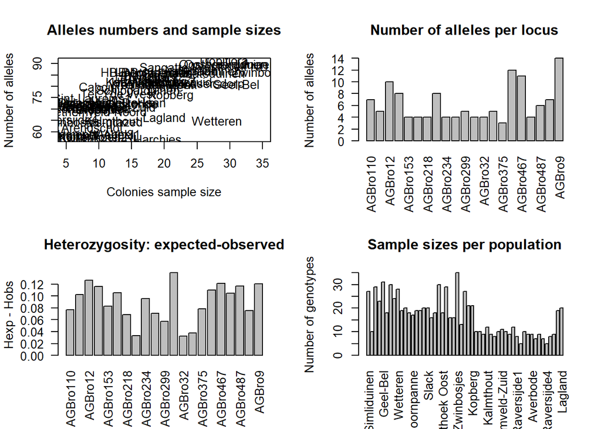

```
## $perloc
##              Ho     Hs     Ht    Dst    Htp   Dstp    Fst   Fstp    Fis   Dest
## AGBro110 0.5800 0.6189 0.6626 0.0437 0.6634 0.0445 0.0659 0.0671 0.0628 0.1168
## AGBro116 0.4787 0.5597 0.5977 0.0380 0.5984 0.0387 0.0635 0.0647 0.1447 0.0879
## AGBro12  0.5872 0.6902 0.7332 0.0430 0.7341 0.0438 0.0586 0.0597 0.1493 0.1415
## AGBro144 0.6386 0.7450 0.7702 0.0252 0.7707 0.0257 0.0327 0.0333 0.1428 0.1007
## AGBro153 0.4447 0.5075 0.5275 0.0200 0.5279 0.0204 0.0380 0.0387 0.1238 0.0415
## AGBro161 0.4679 0.5560 0.5994 0.0435 0.6002 0.0443 0.0725 0.0738 0.1584 0.0997
## AGBro218 0.4393 0.4919 0.5092 0.0173 0.5095 0.0177 0.0340 0.0347 0.1069 0.0348
## AGBro227 0.3978 0.4198 0.4415 0.0217 0.4419 0.0221 0.0492 0.0501 0.0525 0.0381
## AGBro234 0.5425 0.6050 0.6482 0.0432 0.6491 0.0440 0.0667 0.0679 0.1034 0.1115
## AGBro266 0.3306 0.4099 0.4307 0.0208 0.4311 0.0212 0.0483 0.0492 0.1934 0.0359
## AGBro299 0.4092 0.4418 0.4633 0.0216 0.4638 0.0220 0.0465 0.0474 0.0737 0.0394
## AGBro307 0.3323 0.4510 0.4841 0.0332 0.4847 0.0338 0.0685 0.0697 0.2631 0.0615
## AGBro32  0.4853 0.4955 0.5189 0.0233 0.5193 0.0238 0.0450 0.0458 0.0207 0.0471
## AGBro337 0.3928 0.4102 0.4372 0.0269 0.4377 0.0274 0.0616 0.0627 0.0426 0.0465
## AGBro375 0.3719 0.4279 0.4567 0.0289 0.4573 0.0294 0.0632 0.0644 0.1308 0.0515
## AGBro403 0.6876 0.7435 0.8014 0.0579 0.8025 0.0590 0.0723 0.0735 0.0752 0.2301
## AGBro467 0.6525 0.7317 0.8031 0.0714 0.8044 0.0727 0.0889 0.0904 0.1083 0.2711
## AGBro480 0.5074 0.5932 0.6168 0.0236 0.6173 0.0241 0.0383 0.0390 0.1447 0.0592
## AGBro487 0.5191 0.6037 0.6426 0.0389 0.6433 0.0396 0.0605 0.0616 0.1402 0.1000
## AGBro76  0.5356 0.5813 0.6217 0.0404 0.6225 0.0411 0.0649 0.0661 0.0786 0.0983
## AGBro9   0.7089 0.8144 0.8587 0.0443 0.8596 0.0452 0.0516 0.0526 0.1295 0.2434
##
## $overall
##     Ho     Hs     Ht    Dst    Htp   Dstp    Fst   Fstp    Fis   Dest
## 0.5005 0.5666 0.6012 0.0346 0.6018 0.0353 0.0576 0.0586 0.1167 0.0814
```

```
##      name               value
##  Length:115311      Min.   :0.000
##  Class :character   1st Qu.:0.000
##  Mode  :character   Median :0.000
##                     Mean   :0.316
##                     3rd Qu.:0.000
##                     Max.   :2.000
##                     NA's   :4013
```

```
## [1] 115311
```

## Table for basic info per population

```r
#coordinates per pop (centroid of all samples)
coordinates_pops <- metadatapop %>% dplyr::select(Population, MEAN_X, MEAN_Y)
#frequency per pop per year
freq <- as.data.frame(summary(data_genind_popyear$pop)) %>% rename(freq = `summary(data_genind_popyear$pop)`) %>% rownames_to_column("PopulationYear") %>%
   mutate(year = substr(PopulationYear, nchar(PopulationYear)-4+1, nchar(PopulationYear))) %>%
  mutate(Population = substr(PopulationYear, 1, nchar(PopulationYear)-4)) %>%
  mutate(year= as.numeric(year)) %>%
  dplyr::select(-PopulationYear)
#number_pop
number_pop <- metadatapop %>% dplyr::select(Population, Number_pop)



summary_popsyear <- metadatapopyear %>% dplyr::select(Region, Population, Year) %>% left_join(number_pop, by="Population") %>%
  dplyr::select(Region, Number_pop, Population, Year) %>%
  left_join(coordinates_pops, by="Population") %>%
  mutate(year = as.numeric(Year)) %>% dplyr::select(-Year) %>%
  left_join(freq, by=c("Population", "year")) %>%
  arrange(Number_pop, year)
summary_popsyear
```

```
##             Region Number_pop               Population    MEAN_X    MEAN_Y year
## 1  France-Picardie          1             Mt St Frieux -45055.84 147290.02 2018
## 2  France-Picardie          2                    Slack -42871.87 169089.63 2018
## 3  France-Picardie          3                 Sangatte -30478.70 186092.80 2018
## 4   Flanders-coast          4            Westhoek Zuid  23274.35 197883.93 2018
## 5   Flanders-coast          4            Westhoek Zuid  23274.35 197883.93 2020
## 6   Flanders-coast          5                   Cabour  24000.04 196525.26 2018
## 7   Flanders-coast          6                   Veurne  31418.66 196887.77 2018
## 8   Flanders-coast          7               Tropiflora  24109.49 198094.01 2018
## 9   Flanders-coast          7               Tropiflora  24109.49 198094.01 2020
## 10  Flanders-coast          8     Westhoek vissersdorp  23467.29 199618.26 2018
## 11  Flanders-coast          8     Westhoek vissersdorp  23467.29 199618.26 2020
## 12  Flanders-coast          9              Westhoek NO  24120.87 199559.08 2018
## 13  Flanders-coast          9              Westhoek NO  24120.87 199559.08 2020
## 14  Flanders-coast         10            Westhoek Oost  24446.79 199084.82 2018
```

[output cut: 139 more lines]

```r
write.csv(summary_popsyear, file="summary_properties_perpopperyear.csv")



freq_collapsed <- as.data.frame(summary(data_genind$pop)) %>% rename(freq = `summary(data_genind$pop)`) %>% rownames_to_column("Population")

summary_pops <- metadatapop %>% dplyr::select(Region, Number_pop, Population, MEAN_X, MEAN_Y, years_samp) %>%
  left_join(freq_collapsed, by=c("Population")) %>%
  arrange(Number_pop)
summary_pops
```

```
##             Region Number_pop               Population    MEAN_X    MEAN_Y
## 1  France-Picardie          1             Mt St Frieux -45055.84 147290.02
## 2  France-Picardie          2                    Slack -42871.87 169089.63
## 3  France-Picardie          3                 Sangatte -30478.70 186092.80
## 4   Flanders-coast          4            Westhoek Zuid  23274.35 197883.93
## 5   Flanders-coast          5                   Cabour  24000.04 196525.26
## 6   Flanders-coast          6                   Veurne  31418.66 196887.77
## 7   Flanders-coast          7               Tropiflora  24109.49 198094.01
## 8   Flanders-coast          8     Westhoek vissersdorp  23467.29 199618.26
## 9   Flanders-coast          9              Westhoek NO  24120.87 199559.08
## 10  Flanders-coast         10            Westhoek Oost  24446.79 199084.82
## 11  Flanders-coast         11           Oosthoekduinen  26503.16 199039.93
## 12  Flanders-coast         12                Belvedere  27469.46 199611.07
## 13  Flanders-coast         13                 HB-Noord  29615.52 201772.77
## 14  Flanders-coast         14            HB-Doornpanne  29652.17 202069.45
```

[output cut: 93 more lines]

```r
write.csv(summary_pops, file="summary_properties_perpop.csv")
```

## Basic population genetic measures per population

private alleles, allelic richness, heterozygosity, Fis (observed heterozygosity also says something about diversity; difference between both about one of the assumptions of HW not met (small pop size, selection, Wahlund effect,…)).  
In haplodiploidy, one actually expects lower Ho (due to purging, but also drift is faster and have a smaller effective population size due to haplodiploidy; Lester & Selander 1979)  
Fis probably not reliable due to haplodiploidy: higher inbreeding expected anyway (but see Liautard & Sundström (2005) Insects Sociaux, for estimate of inbreeding for haplodiploids based on individual-based level, using relatedness-measures)

Allelic richness:  
* lowest in Wetteren, Kortenhoeff, Kalmthout2, Harchies, Lagland  
* highest at westcoast, slightly decreasing towards east coast  
* further decreasing in Kempen  
He-Ho:  
* inbreeding high in midcoast (small populations that have inbreeding, although connected to rest of coast, see Fst below)  
* inbreeding higher in some populations in Kempen  
* inbreeding high in Wallonia  
* inbreeding (surprisingly) low in Wetteren, Kortenhoeff, Kalmthout2 (Hamont-Achel), while these are quite differentiated (Fst) and have low allelic richness. Possibility: bottleneck (Moyra’s thesis, Molecular Ecology book p109-110)?

```r
#private alleles
private_alleles <- private_alleles(data_genind, count.alleles=F) %>% apply(MARGIN = 1, FUN = sum)
(private_alleles <- as.data.frame(private_alleles) %>%
  add_rownames("pop") %>% arrange(private_alleles) %>%
    rmarkdown::paged_table())
```

| pop | private_alleles |
| --- | --- |
| Simliduinen | 0 |
| Cabour | 0 |
| Westhoek vissersdorp | 0 |
| Karthuizerduinen | 0 |
| Oostvoordduinen | 0 |
| Astridlaan | 0 |
| Wetteren | 0 |
| Sangatte | 0 |
| HB-Pylyserlaan | 0 |
| HB-Doornpanne | 0 |

[output cut: 43 more lines]

```r
#doesn't say much at this scale probably (small scales; probably more informative when looking between regions)

#allelic richness
#Basic population statistics
#allelic richeness
AR <- as_tibble(allelic.richness(data_genind)$Ar) #for each locus separately
nrow(AR) #number of loci
```

```
## [1] 21
```

```r
#change with dplyr to mean and Sd for each location
AR_mean <- AR %>% summarise(across(everything(), mean, na.rm=TRUE))
AR_sd <- AR %>% summarise(across(everything(), sd, na.rm=TRUE))

AR_pop <- as_tibble(t(AR_mean %>% bind_rows(AR_sd)), rownames = "pop") %>%
  rename(mean=V1, sd=V2) %>% mutate(se = sd/sqrt(21))
```

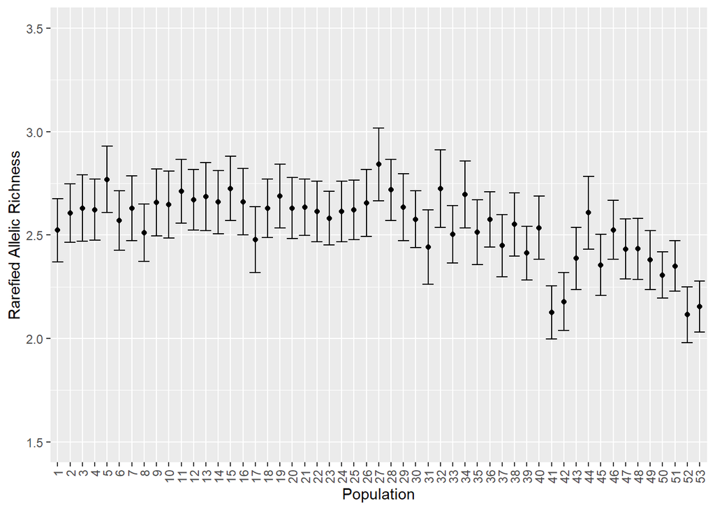

```r
AR_pop <- AR_pop %>% left_join(metadatapop, by=c("pop"="Population"))

#make a graph for allelic richness
plot_AR <- ggplot(AR_pop, aes(x=reorder(as.character(Number_pop), Number_pop), y=mean)) +
  geom_point() +  geom_errorbar(aes(ymin=mean-se, ymax=mean+se)) +
  xlab("Population") + ylab("Rarefied Allelic Richness") +  ylim(c(1.5, 3.5)) +
  theme(axis.text.x = element_text(angle = 90, vjust=0.5, hjust=1))
plot_AR
```

```r
#per region
(AR_region <- AR_pop %>% group_by(Region2) %>%
  summarize(meanAR = mean(mean), sdAR=sd(mean), minAR=min(mean), maxAR=max(mean)))
```

```
## # A tibble: 2 x 5
##   Region2 meanAR   sdAR minAR maxAR
##   <fct>    <dbl>  <dbl> <dbl> <dbl>
## 1 Coast     2.61 0.0914  2.41  2.84
## 2 Inland    2.33 0.154   2.11  2.61
```

```r
t.test(mean~Region2, data=AR_pop)
```

```
##
##  Welch Two Sample t-test
##
## data:  mean by Region2
## t = 6.2142, df = 14.84, p-value = 1.739e-05
## alternative hypothesis: true difference in means between group Coast and group Inland is not equal to 0
## 95 percent confidence interval:
##  0.1840493 0.3764954
## sample estimates:
##  mean in group Coast mean in group Inland
##             2.614713             2.334441
```

```r
#Heterozygosities
Ho <- as_tibble(basic.stats(data_genind)$Ho)
He <- as_tibble(basic.stats(data_genind)$Hs)
nrow(Ho)
```

```
## [1] 21
```

```r
Ho_mean <- Ho %>% summarise(across(everything(), mean, na.rm=TRUE))
Ho_sd <- Ho %>% summarise(across(everything(), sd, na.rm=TRUE))
He_mean <- He %>% summarise(across(everything(), mean, na.rm=TRUE))
He_sd <- He %>% summarise(across(everything(), sd, na.rm=TRUE))

Ho_pop <- as_tibble(t(Ho_mean %>% bind_rows(Ho_sd)), rownames = "pop") %>%
  rename(H_mean=V1, H_sd=V2) %>% mutate(H_se=H_sd/sqrt(21)) %>%
  add_column(H_measure = "Ho")
He_pop <- as_tibble(t(He_mean %>% bind_rows(He_sd)), rownames = "pop") %>%
  rename(H_mean=V1, H_sd=V2) %>% mutate(H_se=H_sd/sqrt(21)) %>%
  add_column(H_measure = "He")

(Ho_region <- Ho_pop %>% left_join(metadatapop, by=c("pop"="Population")) %>% group_by(Region2) %>%
  summarize(meanHo = mean(H_mean), sdHo = sd(H_mean), minHo=min(H_mean), maxHo=max(H_mean)))
```

```
## # A tibble: 2 x 5
##   Region2 meanHo   sdHo minHo maxHo
##   <fct>    <dbl>  <dbl> <dbl> <dbl>
## 1 Coast    0.518 0.0611 0.364 0.619
## 2 Inland   0.446 0.0650 0.330 0.540
```

```r
t.test(H_mean~Region2, data=Ho_pop %>% left_join(metadatapop, by=c("pop"="Population")))
```

```
##
##  Welch Two Sample t-test
##
## data:  H_mean by Region2
## t = 3.503, df = 19.381, p-value = 0.002323
## alternative hypothesis: true difference in means between group Coast and group Inland is not equal to 0
## 95 percent confidence interval:
##  0.02889537 0.11439708
## sample estimates:
##  mean in group Coast mean in group Inland
##            0.5180352            0.4463890
```

```r
(He_region <- He_pop %>% left_join(metadatapop, by=c("pop"="Population")) %>% group_by(Region2) %>%
  summarize(meanHe = mean(H_mean), sdHe= sd(H_mean), minHo=min(H_mean), maxHo=max(H_mean)))
```

```
## # A tibble: 2 x 5
##   Region2 meanHe   sdHe minHo maxHo
##   <fct>    <dbl>  <dbl> <dbl> <dbl>
## 1 Coast    0.587 0.0259 0.528 0.640
## 2 Inland   0.507 0.0472 0.433 0.579
```

```r
t.test(H_mean~Region2, data=He_pop %>% left_join(metadatapop, by=c("pop"="Population")))
```

```
##
##  Welch Two Sample t-test
##
## data:  H_mean by Region2
## t = 5.8197, df = 14.413, p-value = 3.96e-05
## alternative hypothesis: true difference in means between group Coast and group Inland is not equal to 0
## 95 percent confidence interval:
##  0.05048613 0.10916697
## sample estimates:
##  mean in group Coast mean in group Inland
##            0.5866885            0.5068619
```

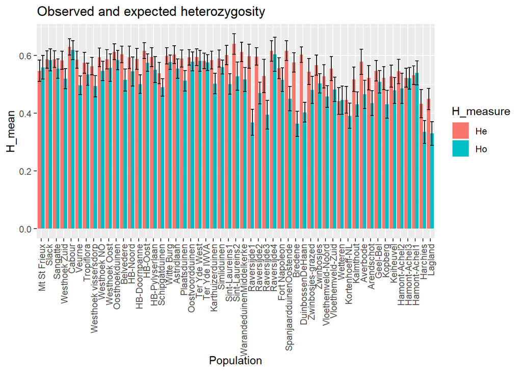

```r
H_pop_diff <- rename(Ho_pop, Ho_mean = H_mean, Ho_sd = H_sd, Ho_se=H_se, Ho_measure = H_measure) %>%
  left_join(He_pop, by=c("pop")) %>%
  mutate(He_Ho_mean = H_mean - Ho_mean, He_Ho_se = H_se + Ho_se) %>% left_join(metadatapop, by=c("pop"="Population"))

H_pop <- Ho_pop %>% bind_rows(He_pop) %>%
  mutate(pop=as.character(pop)) %>%
  left_join(metadatapop, by=c("pop"="Population"))
plot_H <- ggplot(H_pop, aes(x=reorder(pop, Number_pop), y=H_mean, fill=H_measure)) +
  geom_bar(stat = "identity", position="dodge") +
  geom_errorbar(aes(ymin=H_mean-H_se, ymax=H_mean+H_se), position="dodge") +
  xlab("Population") + ggtitle("Observed and expected heterozygosity") +
  theme(axis.text.x = element_text(angle = 90, vjust=0.5, hjust=1))
plot_H
```

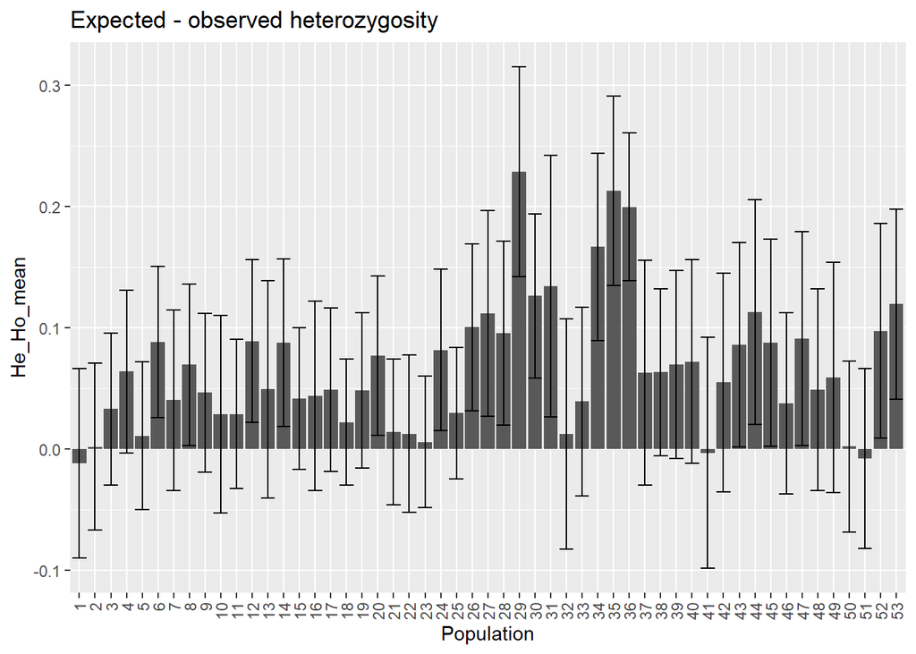

```r
plot_Hdiff <- ggplot(H_pop_diff, aes(x=reorder(as.character(Number_pop), Number_pop), y=He_Ho_mean)) +
  geom_bar(stat="identity") +
  geom_errorbar(aes(ymin = He_Ho_mean-He_Ho_se, ymax = He_Ho_mean+He_Ho_se)) +
  xlab("Population") + ggtitle("Expected - observed heterozygosity") +
  theme(axis.text.x = element_text(angle=90, vjust=0.5, hjust=1))
plot_Hdiff
```

```r
#watch out for effect of low sample sizes!


Fis <- as_tibble(basic.stats(data_genind)$Fis)
Fis_mean <- Fis %>% summarise(across(everything(), mean, na.rm=TRUE))
Fis_sd <- Fis %>% summarise(across(everything(), sd, na.rm=TRUE))

Fis_pop <- as_tibble(t(Fis_mean %>% bind_rows(Fis_sd)), rownames="pop") %>%
  rename(Fis_mean=V1, Fis_sd=V2) %>% mutate(Fis_se=Fis_sd/sqrt(21)) %>%
  left_join(metadatapop, by=c("pop"="Population"))

(Fis_region <- Fis_pop %>% group_by(Region2) %>%
  summarize(meanFis = mean(Fis_mean), sdFis= sd(Fis_mean), minFis=min(Fis_mean), maxFis=max(Fis_mean)))
```

```
## # A tibble: 2 x 5
##   Region2 meanFis  sdFis  minFis maxFis
##   <fct>     <dbl>  <dbl>   <dbl>  <dbl>
## 1 Coast     0.109 0.0942 -0.0216  0.361
## 2 Inland    0.115 0.0931 -0.0254  0.269
```

```r
t.test(Fis_mean~Region2, data=Fis_pop)
```

```
##
##  Welch Two Sample t-test
##
## data:  Fis_mean by Region2
## t = -0.17603, df = 20.597, p-value = 0.862
## alternative hypothesis: true difference in means between group Coast and group Inland is not equal to 0
## 95 percent confidence interval:
##  -0.06732888  0.05683177
## sample estimates:
##  mean in group Coast mean in group Inland
##            0.1093880            0.1146366
```

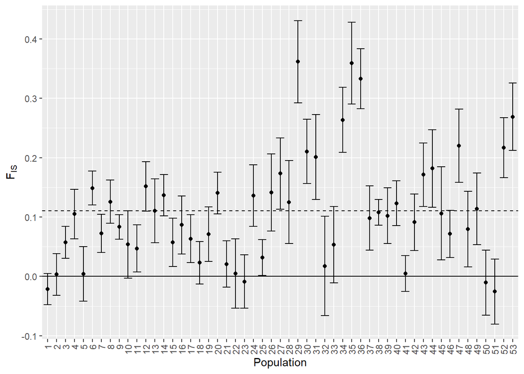

```r
write.csv(Fis_pop, "FIS-values/Fis_full.csv")

plot_Fis <- ggplot(Fis_pop, aes(x=reorder(as.character(Number_pop), Number_pop), y=Fis_mean)) +
  geom_point() + geom_errorbar(aes(ymin=Fis_mean-Fis_se, ymax=Fis_mean+Fis_se)) +
  xlab("Population") + ylab(expression(F["IS"])) +
  theme(axis.text.x  = element_text(angle = 90, vjust=0.5, hjust=1)) +
  geom_hline(yintercept=0) + geom_hline(yintercept=mean(Fis_pop$Fis_mean), linetype="dashed")
plot_Fis
```

### Adding the population statistics to the table

```r
#Add all this info to the table above

summary_pops_stats <- summary_pops %>% full_join(private_alleles, by=c("Population"="pop"))  %>%#add private alleles
  full_join(AR_pop %>% rename("AR"="mean", "AR_sd"="sd", "AR_se"="se") %>% dplyr::select(pop, AR, AR_sd, AR_se), #add Allelic Richness
            by=c("Population"="pop")) %>%
  full_join(He_pop %>% rename("He_mean"="H_mean", "He_sd"="H_sd", "He_se"="H_se") %>%  #add expected heterozygosity
              dplyr::select(pop, He_mean, He_sd, He_se),
            by=c("Population"="pop")) %>%
  full_join(Ho_pop %>% rename("Ho_mean"="H_mean", "Ho_sd"="H_sd", "Ho_se"="H_se") %>%  #add observed heterozygosity
              dplyr::select(pop, Ho_mean, Ho_sd, Ho_se),
            by=c("Population"="pop")) %>%
  full_join(Fis_pop %>% dplyr::select(pop, Fis_mean, Fis_sd, Fis_se), #add inbreeding coefficient
            by=c("Population"="pop"))

# write.csv(summary_pops_stats, "summary_pop_statistics.csv")
```

## Pairwise Fst values

Calculated with package diveRsity. Lines are commented when it is run.

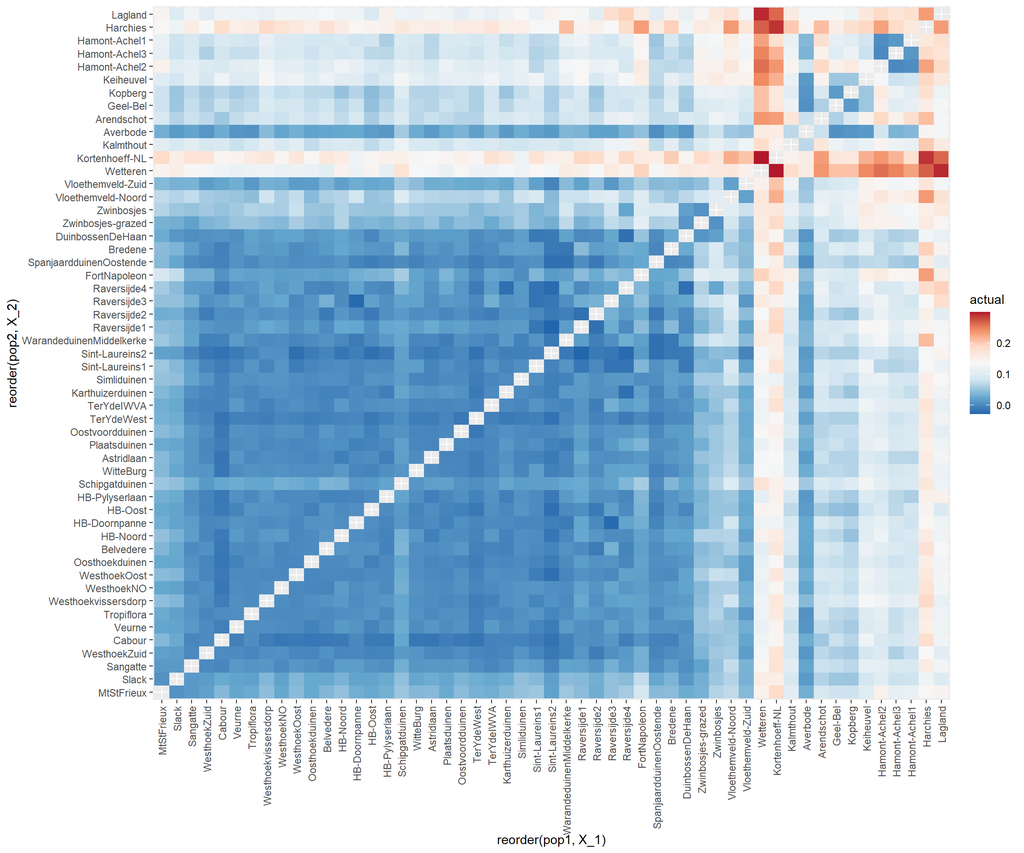

```r
#to work with package diveRsity: convert genind to genepop-file
#https://rdrr.io/github/romunov/zvau/man/writeGenPop.html
# genpop <- genind_to_genepop(data_genind, "all_genind_genepop.txt")
#
# # #
# gendata <- readGenepop(infile = "all_genind_genepop.txt", gp = 3, bootstrap = F)
# diffs <- fastDivPart(infile = "all_genind_genepop.txt", outfile = "./differentation diveRsity/13092021", pairwise=T)
# #
# fst <- diffCalc(infile = "all_genind_genepop.txt", outfile="diffs",
#                 fst=T, pairwise=T, bs_pairwise=T, boots = 999)
# write.table(fst$bs_pairwise$Fst, "Fst_diveRsity1000boots.txt")
# write.table(fst$bs_pairwise$D, "D_diveRsity1000boots.txt")
# write.table(fst$bs_pairwise$gst, "gst_diveRsity1000boots.txt")
# write.table(fst$bs_pairwise$Gst, "Gst_diveRsity1000boots.txt")
# write.table(fst$bs_pairwise$GGst, "GGst_diveRsity1000boots.txt")

metadatapop_assign <- metadatapop %>% mutate(pop = gsub('\\ ', "", Population))
#define function to read differentation measure from above files
read_diffmeasure <- function(file = "Fst_diveRsity1000boots.txt"){
  diff_df <-  read.table(file, head=T) %>%
  separate(populations, c("pop1", "pop2"), sep="\\s*vs\\s*") %>%
  mutate(pop1 = gsub("*_.*", "", pop1)) %>%
  mutate(pop2 = gsub("*_.*", "", pop2))
  #add all all data bind_rows, but with pop1 and pop2 swapped
  #remove all duplicates?
  diff_df_all <- diff_df %>% dplyr::select(pop2, pop1, actual, lower, upper) %>%
    rename("pop1"="pop2", "pop2"="pop1") %>%
    bind_rows(diff_df)
  #join with metadata to get right order in pop1 and pop2
  diff_df_all <- diff_df_all %>%
    left_join(metadatapop_assign %>%
                dplyr::select(pop, Number_pop) %>% rename("X_1"="Number_pop"),
              by=c("pop1"="pop")) %>%
    left_join(metadatapop_assign %>%
                dplyr::select(pop, Number_pop) %>% rename("X_2"="Number_pop"),
              by=c("pop2"="pop"))
  return(diff_df_all)
}

fst_df_all <- read_diffmeasure("Fst_diveRsity1000boots.txt")

fst_tile <-  ggplot(fst_df_all, aes(x=reorder(pop1, X_1), y=reorder(pop2, X_2), fill=actual)) +
  geom_tile() +
  scale_fill_distiller(palette = "RdBu") +
  theme(axis.text.x = element_text(angle = 90, vjust = 0.5, hjust=1))
fst_tile
```

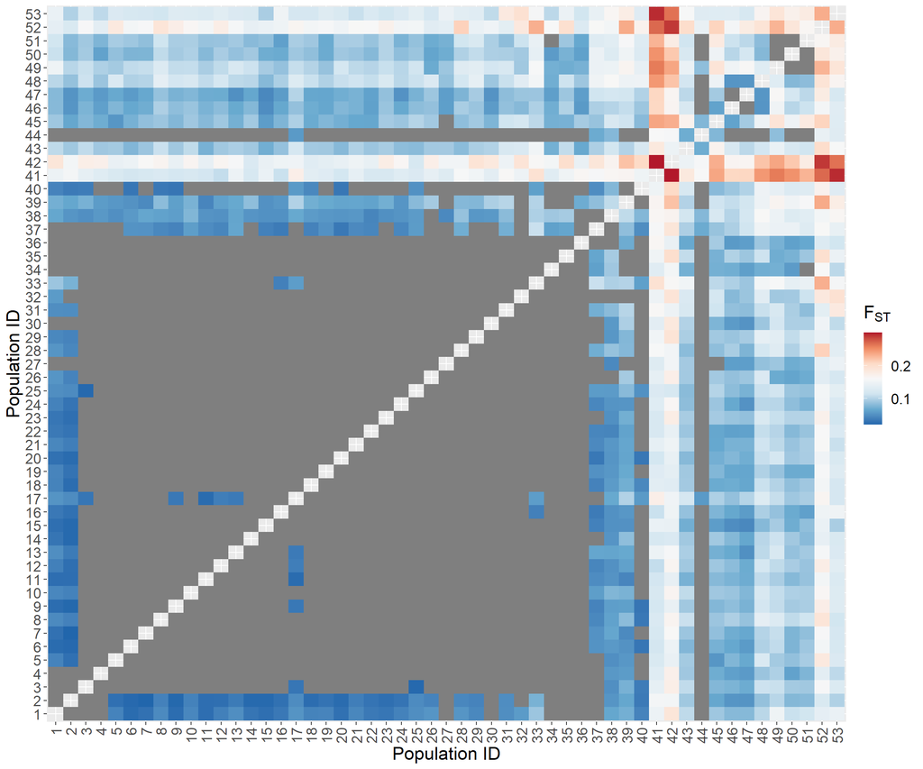

```r
#leave out non-sign fst-values
fst_df_sign <- fst_df_all %>% mutate(Fst = ifelse(lower < 0 & upper > 0, NA, actual))

fst_tile_sign <-  ggplot(fst_df_sign, aes(x=reorder(as.character(X_1), X_1), y=reorder(as.character(X_2), X_2), fill=Fst)) + #x=reorder(pop1, X_1), y=reorder(pop2, X_2)
  geom_tile() +
  xlab("Population ID") + ylab("Population ID") +
  scale_fill_distiller(palette = "RdBu", direction=-1, name=expression(F[ST])) +#RdYlBu
  theme(axis.text.x = element_text(angle = 90, vjust = 0.5, hjust=1),
        text = element_text(size = 17))
fst_tile_sign
```

```r
#table to summarise mean pairwise D per pop
(meanfst_pop <- fst_df_all %>% group_by(pop1) %>% summarise(Fstmean=mean(actual), sd=sd(actual)) %>% arrange(desc(Fstmean)) %>%
    left_join(dplyr::select(metadatapop_assign, pop, Number_pop, Region), by=c("pop1"="pop")) %>%
    rmarkdown::paged_table())
```

| pop1 | Fstmean | sd | Number_pop | Region |
| --- | --- | --- | --- | --- |
| Kortenhoeff-NL | 0.17345962 | 0.03885866 | 42 | Flanders-inland |
| Harchies | 0.17137692 | 0.03533691 | 52 | Wallonia |
| Wetteren | 0.16116731 | 0.04932619 | 41 | Flanders-inland |
| Lagland | 0.14196154 | 0.03886885 | 53 | Wallonia |
| Hamont-Achel2 | 0.11875385 | 0.04709533 | 49 | Flanders-inland |
| Keiheuvel | 0.11597885 | 0.03852422 | 48 | Flanders-inland |
| Kalmthout | 0.10552500 | 0.02879402 | 43 | Flanders-inland |
| Arendschot | 0.10080577 | 0.04333835 | 45 | Flanders-inland |
| Hamont-Achel1 | 0.09992115 | 0.04001265 | 51 | Flanders-inland |
| Hamont-Achel3 | 0.09785192 | 0.04335418 | 50 | Flanders-inland |

[output cut: 43 more lines]

```r
write.csv(meanfst_pop, "average pairwise Fst per pop.csv")

####Add regions as second level of axes: https://stackoverflow.com/questions/20571306/multi-row-x-axis-labels-in-ggplot-line-chart
```

## Alternatives for Fst: Djost, Gst (+corrections)

Djost, calculated above (Jost 2008, good for highly polymorphic markers); Gst (+ G’st, G’’st)

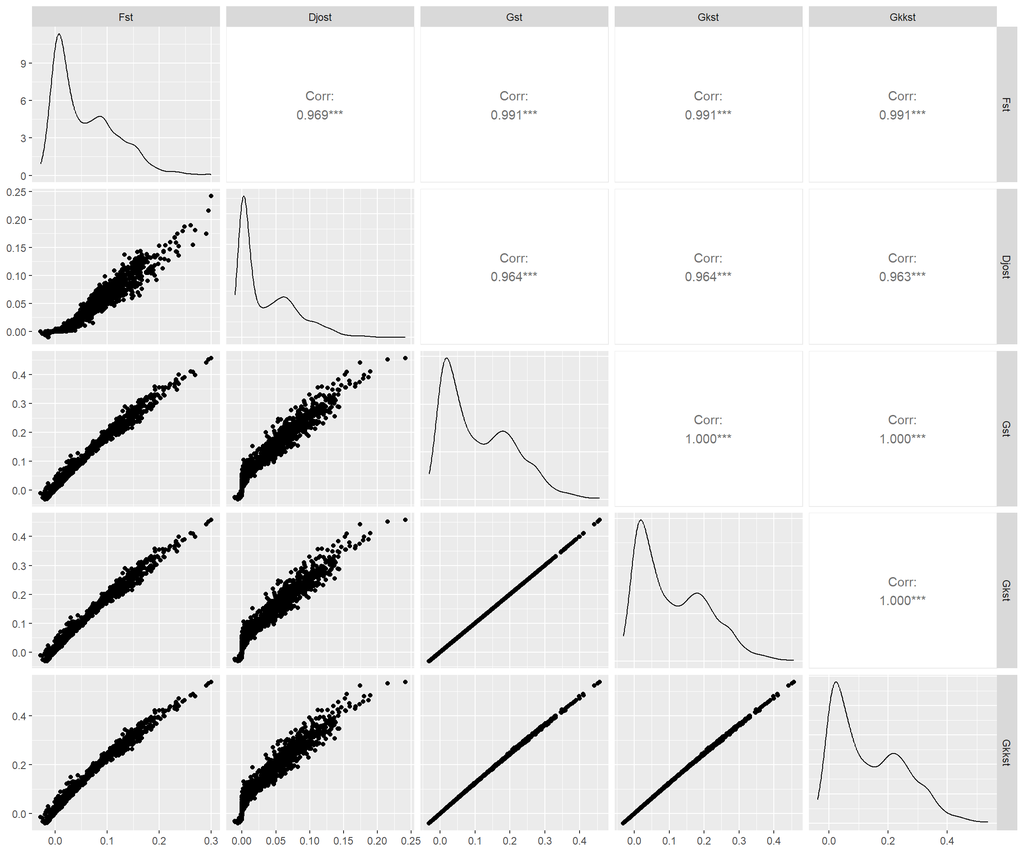

```r
# read measures
D_df_all <- read_diffmeasure("D_diveRsity1000boots.txt")
Gst_df_all <- read_diffmeasure("gst_diveRsity1000boots.txt")
Gkst_df_all <- read_diffmeasure("Gst_diveRsity1000boots.txt")
Gkkst_df_all <- read_diffmeasure("GGst_diveRsity1000boots.txt")

#bind measures into one dataframe

diffmeasures <- rename(fst_df_all, Fst=actual, Fst_lower=lower, Fst_upper=upper) %>%
  left_join(rename(D_df_all, Djost=actual, Djost_lower=lower, Djost_upper=upper), by=c("pop1", "pop2")) %>%
  left_join(rename(Gst_df_all, Gst=actual, Gst_lower=lower, Gst_upper=upper), by=c("pop1", "pop2")) %>%
  left_join(rename(Gkst_df_all, Gkst=actual,Gkst_lower=lower, Gkst_upper=upper), by=c("pop1", "pop2")) %>%
  left_join(rename(Gkkst_df_all, Gkkst=actual,Gkkst_lower=lower, Gkkst_upper=upper), by=c("pop1", "pop2"))

ggpairs(dplyr::select(diffmeasures, Fst, Djost, Gst, Gkst, Gkkst))
```

### Plot Djost

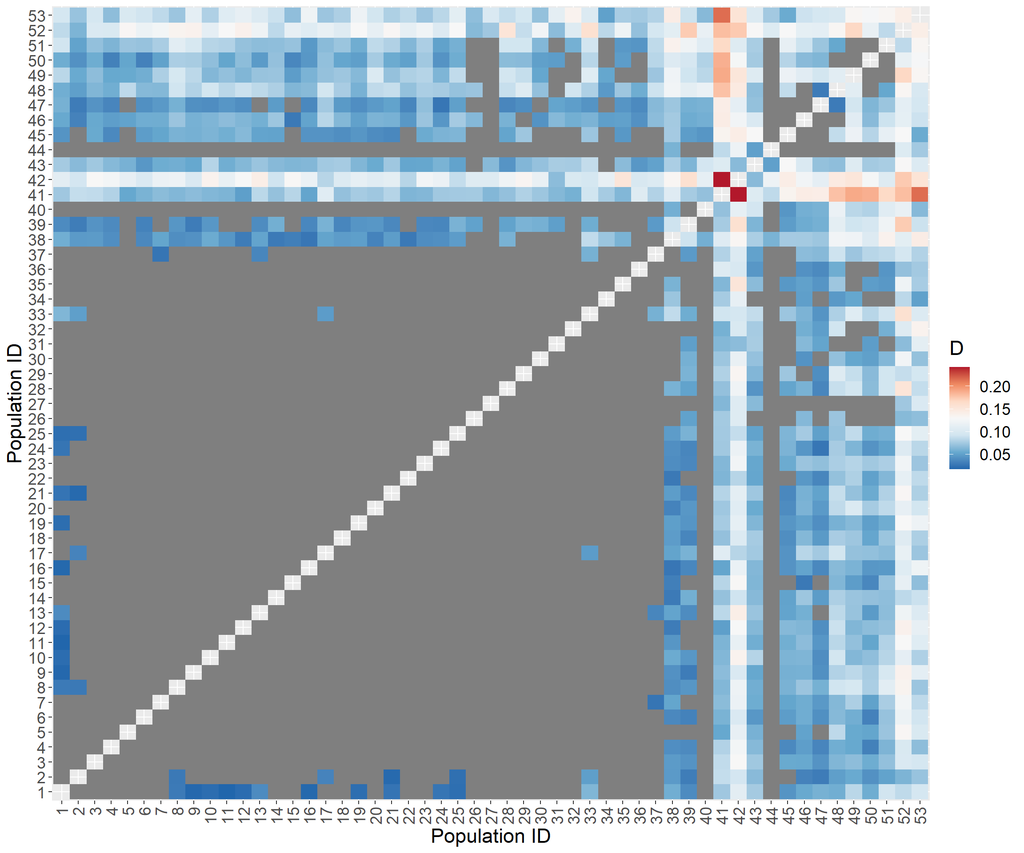

```r
#leave out non-sign values
D_df_sign <- D_df_all %>% mutate(Djost = ifelse(lower < 0 & upper > 0, NA, actual))


D_tile_sign <-  ggplot(D_df_sign, aes(x=reorder(as.character(X_1), X_1), y=reorder(as.character(X_2), X_2), fill=Djost)) +
  geom_tile() +
  xlab("Population ID") + ylab("Population ID") +
  scale_fill_distiller(palette = "RdBu", direction=-1, name="D") +
  theme(axis.text.x = element_text(angle = 90, vjust = 0.5, hjust=1),
        text = element_text(size = 17))
D_tile_sign
```

```r
#table to summarise mean pairwise D per pop
(meanD_pop <- D_df_all %>% group_by(pop1) %>% summarise(Djost=mean(actual), sd=sd(actual)) %>% arrange(desc(Djost)) %>%
    left_join(dplyr::select(metadatapop_assign, pop, Number_pop, Region), by=c("pop1"="pop")) %>%
    rmarkdown::paged_table())
```

| pop1 | Djost | sd | Number_pop | Region |
| --- | --- | --- | --- | --- |
| Kortenhoeff-NL | 0.11878269 | 0.02823310 | 42 | Flanders-inland |
| Harchies | 0.11631731 | 0.02770079 | 52 | Wallonia |
| Lagland | 0.09693846 | 0.02893548 | 53 | Wallonia |
| Wetteren | 0.09437115 | 0.04538280 | 41 | Flanders-inland |
| Keiheuvel | 0.07859038 | 0.02959708 | 48 | Flanders-inland |
| Hamont-Achel2 | 0.07715385 | 0.03554817 | 49 | Flanders-inland |
| Hamont-Achel1 | 0.07285385 | 0.03191856 | 51 | Flanders-inland |
| Kalmthout | 0.06990192 | 0.01928217 | 43 | Flanders-inland |
| Hamont-Achel3 | 0.06109231 | 0.03209436 | 50 | Flanders-inland |
| Geel-Bel | 0.06089615 | 0.02601359 | 46 | Flanders-inland |

[output cut: 43 more lines]

```r
write.csv(meanD_pop, "average pairwise D per pop.csv")

#tables for average D's etc
```

### plot Gst

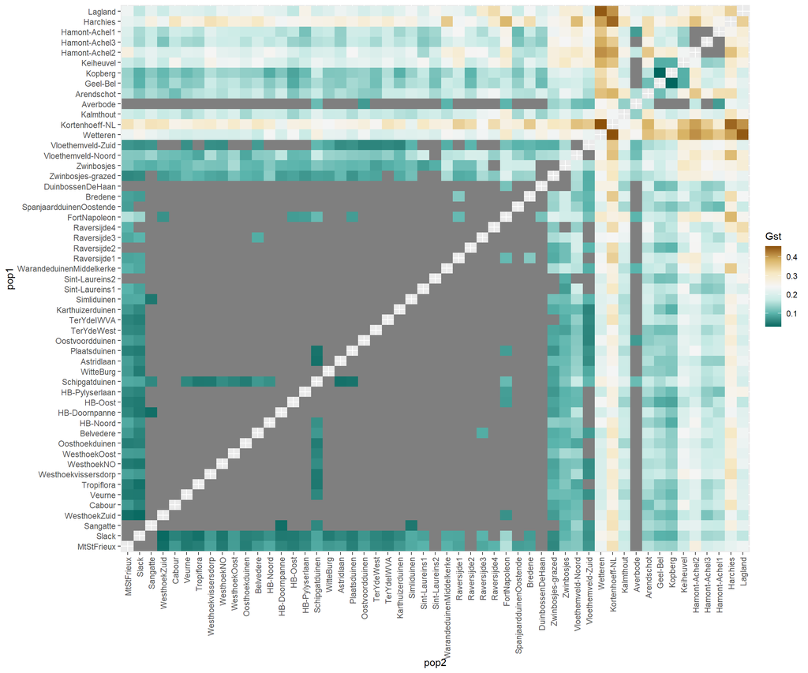

```r
#leave out non-sign values
Gst_df_sign <- Gst_df_all %>% mutate(Gst = ifelse(lower < 0 & upper > 0, NA, actual))

Gst_tile_sign <-  ggplot(Gst_df_sign, aes(x=reorder(pop2, X_2), y=reorder(pop1, X_1), fill=Gst)) +
  geom_tile() +
  xlab("pop2") + ylab("pop1") +
  scale_fill_distiller(palette = "BrBG") +
  theme(axis.text.x = element_text(angle = 90, vjust = 0.5, hjust=1))
Gst_tile_sign
```

```r
#table to summarise mean pairwise Fst per pop
(meanGst_pop <- Gst_df_all %>% group_by(pop1) %>% summarise(Gst=mean(actual), sd=sd(actual)) %>% arrange(desc(Gst)) %>%
    rmarkdown::paged_table())
```

| pop1 | Gst | sd |
| --- | --- | --- |
| Kortenhoeff-NL | 0.30266538 | 0.05229838 |
| Harchies | 0.28336538 | 0.05006054 |
| Wetteren | 0.25521154 | 0.07340061 |
| Lagland | 0.23711154 | 0.05552834 |
| Hamont-Achel2 | 0.23059615 | 0.07374497 |
| Keiheuvel | 0.21825385 | 0.06102197 |
| Kalmthout | 0.19592885 | 0.04039386 |
| Arendschot | 0.19057885 | 0.06562074 |
| Hamont-Achel1 | 0.18533462 | 0.06355671 |
| Hamont-Achel3 | 0.18068846 | 0.06667268 |

[output cut: 43 more lines]

## Nei’s genetic distance

poppr function nei.dist or hierfstat (but is dat Nei’s distance?) hierfstat::genet.dist: Ds (Nei’s standard genetic distance) confidence intervals? Toch Genalex or other stand alone program?

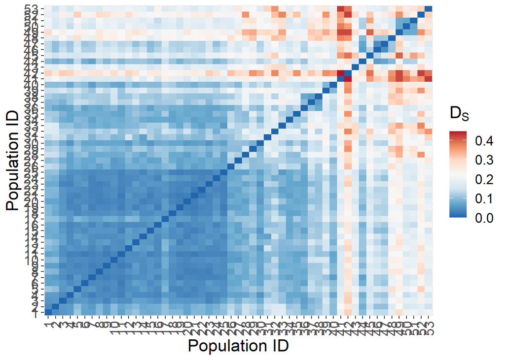

```r
nei.dist_m <- as.data.frame(as.matrix(hierfstat::genet.dist(data_genind, method="Ds")))
colnames(nei.dist_m) <- popNames(data_genind) #add popnames to columns
rownames(nei.dist_m) <- popNames(data_genind) #add popnames to rows

nei.dist_df <- nei.dist_m %>% rownames_to_column(var="pop1") %>%
  pivot_longer(cols = Simliduinen:(ncol(nei.dist_m)+1), names_to="pop2", values_to="actual") %>% #put the values from matrix -> long format
  left_join(metadatapop_assign %>% #adding the number of the pops
                dplyr::select(Population, Number_pop) %>% rename("X_1"="Number_pop"),
              by=c("pop1"="Population")) %>%
    left_join(metadatapop_assign %>%
                dplyr::select(Population, Number_pop) %>% rename("X_2"="Number_pop"),
              by=c("pop2"="Population"))

#write.csv(nei.dist_df, "Neisgeneticdistance_hierfstat.csv")

#plot Nei's distance

Ds_tile <-  ggplot(nei.dist_df, aes(x=reorder(as.character(X_1), X_1), y=reorder(as.character(X_2), X_2), fill=actual)) + #x=reorder(pop1, X_1), y=reorder(pop2, X_2)
  geom_tile() +
  xlab("Population ID") + ylab("Population ID") +
  scale_fill_distiller(palette = "RdBu", direction=-1, name=expression(D[S])) +#RdYlBu
  theme(axis.text.x = element_text(angle = 90, vjust = 0.5, hjust=1),
        text = element_text(size = 17))
Ds_tile
```

```r
#average
(meanDs_pop <- nei.dist_df %>%
    dplyr::filter(pop1!=pop2) %>%
    group_by(pop1) %>% summarise(Ds=mean(actual), sd=sd(actual)) %>% arrange(desc(Ds)) %>%
    left_join(dplyr::select(metadatapop_assign, Population, Number_pop, Region), by=c("pop1"="Population")) %>%
    rmarkdown::paged_table())
```

| pop1 | Ds | sd | Number_pop | Region |
| --- | --- | --- | --- | --- |
| Kortenhoeff-NL | 0.29613057 | 0.05668330 | 42 | Flanders-inland |
| Hamont-Achel2 | 0.26185717 | 0.06612891 | 49 | Flanders-inland |
| Harchies | 0.26072868 | 0.05249537 | 52 | Wallonia |
| Keiheuvel | 0.23417029 | 0.05720584 | 48 | Flanders-inland |
| Wetteren | 0.23329298 | 0.07634107 | 41 | Flanders-inland |
| Lagland | 0.21865370 | 0.05770438 | 53 | Wallonia |
| Arendschot | 0.21146107 | 0.06356168 | 45 | Flanders-inland |
| Kalmthout | 0.20473541 | 0.03918688 | 43 | Flanders-inland |
| Hamont-Achel1 | 0.20384381 | 0.05504116 | 51 | Flanders-inland |
| Hamont-Achel3 | 0.20065995 | 0.05658605 | 50 | Flanders-inland |

[output cut: 43 more lines]

```r
write.csv(meanDs_pop, "average Nei's genetic distance per pop.csv")
```